# Credit Card Fraud EDA

GHtjm

2024-06-11

# Table of Contents

1. Introduction
2. Exploration Plans
3. Initial Exploratory Data Analysis (EDA)
4. Predictive Models
   - Random Forest
   - LightGBM
   - XGBoost
5. Conclusion

# Introduction

The dataset contains transactions made by credit cards in September 2013 by European cardholders. This dataset presents transactions that occurred in two days, where we have 492 frauds out of 284,807 transactions. The dataset is highly unbalanced, the positive class (frauds) account for 0.172% of all transactions. It contains only numerical input variables which are the result of a PCA transformation. Unfortunately, due to confidentiality, the original features and additional background information cannot be provided. Features V1, V2, … V28 are the principal components obtained with PCA, the only features which have not been transformed with PCA are ‘Time’ and ‘Amount’. Feature ‘Time’ contains the seconds elapsed between each transaction and the first transaction in the dataset. The feature ‘Amount’ is the transaction Amount, this feature can be used for example-dependant cost-sensitive learning. Feature ‘Class’ is the response variable, and it takes value 1 in case of fraud and 0 otherwise.

# Exploration Plans

# Initial Exploratory Data Analysis (EDA)

```r
# Loading appropriate libraries
library(data.table)
library(ggplot2)
library(caret)
library(randomForest)
library(lightgbm)
library(xgboost)
library(pROC)
library(tidyverse)
print("Libraries loaded")
```

```
## [1] "Libraries loaded"
```

```r
# Load dataset
data_path <- file.choose()
creditcard <- fread(data_path)
print("Data loaded successfully")
```

```
## [1] "Data loaded successfully"
```

```r
head(creditcard)
```

```
##     Time         V1          V2        V3         V4          V5          V6
##    <num>      <num>       <num>     <num>      <num>       <num>       <num>
## 1:     0 -1.3598071 -0.07278117 2.5363467  1.3781552 -0.33832077  0.46238778
## 2:     0  1.1918571  0.26615071 0.1664801  0.4481541  0.06001765 -0.08236081
## 3:     1 -1.3583541 -1.34016307 1.7732093  0.3797796 -0.50319813  1.80049938
## 4:     1 -0.9662717 -0.18522601 1.7929933 -0.8632913 -0.01030888  1.24720317
## 5:     2 -1.1582331  0.87773675 1.5487178  0.4030339 -0.40719338  0.09592146
## 6:     2 -0.4259659  0.96052304 1.1411093 -0.1682521  0.42098688 -0.02972755
##             V7          V8         V9         V10        V11         V12
##          <num>       <num>      <num>       <num>      <num>       <num>
## 1:  0.23959855  0.09869790  0.3637870  0.09079417 -0.5515995 -0.61780086
## 2: -0.07880298  0.08510165 -0.2554251 -0.16697441  1.6127267  1.06523531
## 3:  0.79146096  0.24767579 -1.5146543  0.20764287  0.6245015  0.06608369
## 4:  0.23760894  0.37743587 -1.3870241 -0.05495192 -0.2264873  0.17822823
## 5:  0.59294075 -0.27053268  0.8177393  0.75307443 -0.8228429  0.53819555
```

[output cut: 25 more lines]

```r
# Preprocess the data
creditcard$Class <- as.factor(creditcard$Class)
creditcard <- na.omit(creditcard)
print("Completed data preprocessing")
```

```
## [1] "Completed data preprocessing"
```

```r
# Summary statistics
summary(creditcard)
```

```
##       Time              V1                  V2                  V3
##  Min.   :     0   Min.   :-56.40751   Min.   :-72.71573   Min.   :-48.3256
##  1st Qu.: 54202   1st Qu.: -0.92037   1st Qu.: -0.59855   1st Qu.: -0.8904
##  Median : 84692   Median :  0.01811   Median :  0.06549   Median :  0.1799
##  Mean   : 94814   Mean   :  0.00000   Mean   :  0.00000   Mean   :  0.0000
##  3rd Qu.:139321   3rd Qu.:  1.31564   3rd Qu.:  0.80372   3rd Qu.:  1.0272
##  Max.   :172792   Max.   :  2.45493   Max.   : 22.05773   Max.   :  9.3826
##        V4                 V5                   V6                 V7
##  Min.   :-5.68317   Min.   :-113.74331   Min.   :-26.1605   Min.   :-43.5572
##  1st Qu.:-0.84864   1st Qu.:  -0.69160   1st Qu.: -0.7683   1st Qu.: -0.5541
##  Median :-0.01985   Median :  -0.05434   Median : -0.2742   Median :  0.0401
##  Mean   : 0.00000   Mean   :   0.00000   Mean   :  0.0000   Mean   :  0.0000
##  3rd Qu.: 0.74334   3rd Qu.:   0.61193   3rd Qu.:  0.3986   3rd Qu.:  0.5704
##  Max.   :16.87534   Max.   :  34.80167   Max.   : 73.3016   Max.   :120.5895
##        V8                  V9                 V10                 V11
##  Min.   :-73.21672   Min.   :-13.43407   Min.   :-24.58826   Min.   :-4.79747
##  1st Qu.: -0.20863   1st Qu.: -0.64310   1st Qu.: -0.53543   1st Qu.:-0.76249
##  Median :  0.02236   Median : -0.05143   Median : -0.09292   Median :-0.03276
##  Mean   :  0.00000   Mean   :  0.00000   Mean   :  0.00000   Mean   : 0.00000
##  3rd Qu.:  0.32735   3rd Qu.:  0.59714   3rd Qu.:  0.45392   3rd Qu.: 0.73959
##  Max.   : 20.00721   Max.   : 15.59500   Max.   : 23.74514   Max.   :12.01891
##       V12                V13                V14                V15
##  Min.   :-18.6837   Min.   :-5.79188   Min.   :-19.2143   Min.   :-4.49894
##  1st Qu.: -0.4056   1st Qu.:-0.64854   1st Qu.: -0.4256   1st Qu.:-0.58288
##  Median :  0.1400   Median :-0.01357   Median :  0.0506   Median : 0.04807
##  Mean   :  0.0000   Mean   : 0.00000   Mean   :  0.0000   Mean   : 0.00000
##  3rd Qu.:  0.6182   3rd Qu.: 0.66251   3rd Qu.:  0.4931   3rd Qu.: 0.64882
##  Max.   :  7.8484   Max.   : 7.12688   Max.   : 10.5268   Max.   : 8.87774
##       V16                 V17                 V18
##  Min.   :-14.12985   Min.   :-25.16280   Min.   :-9.498746
##  1st Qu.: -0.46804   1st Qu.: -0.48375   1st Qu.:-0.498850
##  Median :  0.06641   Median : -0.06568   Median :-0.003636
##  Mean   :  0.00000   Mean   :  0.00000   Mean   : 0.000000
##  3rd Qu.:  0.52330   3rd Qu.:  0.39968   3rd Qu.: 0.500807
##  Max.   : 17.31511   Max.   :  9.25353   Max.   : 5.041069
##       V19                 V20                 V21
##  Min.   :-7.213527   Min.   :-54.49772   Min.   :-34.83038
##  1st Qu.:-0.456299   1st Qu.: -0.21172   1st Qu.: -0.22839
##  Median : 0.003735   Median : -0.06248   Median : -0.02945
##  Mean   : 0.000000   Mean   :  0.00000   Mean   :  0.00000
```

[output cut: 8 more lines]

```
##  Max.   : 10.503090   Max.   : 22.52841   Max.   : 4.58455
##       V25                 V26                V27
##  Min.   :-10.29540   Min.   :-2.60455   Min.   :-22.565679
##  1st Qu.: -0.31715   1st Qu.:-0.32698   1st Qu.: -0.070840
##  Median :  0.01659   Median :-0.05214   Median :  0.001342
##  Mean   :  0.00000   Mean   : 0.00000   Mean   :  0.000000
##  3rd Qu.:  0.35072   3rd Qu.: 0.24095   3rd Qu.:  0.091045
##  Max.   :  7.51959   Max.   : 3.51735   Max.   : 31.612198
##       V28                Amount         Class
##  Min.   :-15.43008   Min.   :    0.00   0:284315
##  1st Qu.: -0.05296   1st Qu.:    5.60   1:   492
##  Median :  0.01124   Median :   22.00
##  Mean   :  0.00000   Mean   :   88.35
##  3rd Qu.:  0.07828   3rd Qu.:   77.17
##  Max.   : 33.84781   Max.   :25691.16
```

```r
# Class distribution, 0 = non fraud, 1 = fraud
table(creditcard$Class)
```

```
##
##      0      1
## 284315    492
```

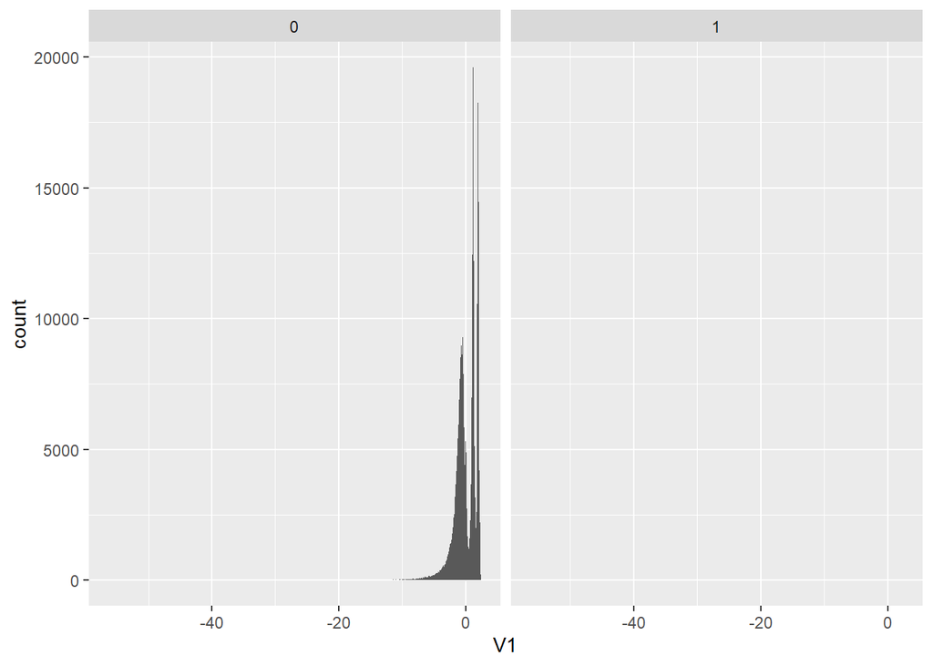

```r
# Visualization
ggplot(creditcard, aes(x = V1)) +
  geom_histogram(binwidth = 0.1) +
  facet_wrap(~ Class)
```

```r
# Begin predictive modelling by Separating the data into train and test sets
set.seed(123)
trainIndex <- createDataPartition(creditcard$Class, p = 0.8, list = FALSE)
trainData <- creditcard[trainIndex, ]
testData <- creditcard[-trainIndex, ]
print("Data split into training and testing sets")
```

```
## [1] "Data split into training and testing sets"
```

```r
# Train the random forest model
rfmodel <- randomForest(Class ~ ., data = trainData, ntree = 100, importance = TRUE)
print("Random Forest model trained")
```

```
## [1] "Random Forest model trained"
```

```r
# create a prediction
rfpred <- predict(rfmodel, testData, type = "prob")[,2]

# Evaluate the prediction
rfpredclass <- ifelse(rfpred > 0.5, 1, 0)
rfcm <- confusionMatrix(as.factor(rfpredclass), testData$Class)
print("Random Forest evaluation completed")
```

```
## [1] "Random Forest evaluation completed"
```

```r
print(rfcm)
```

```
## Confusion Matrix and Statistics
##
##           Reference
## Prediction     0     1
##          0 56856    18
##          1     7    80
##
##                Accuracy : 0.9996
##                  95% CI : (0.9994, 0.9997)
##     No Information Rate : 0.9983
##     P-Value [Acc > NIR] : <2e-16
##
##                   Kappa : 0.8646
##
##  Mcnemar's Test P-Value : 0.0455
##
##             Sensitivity : 0.9999
##             Specificity : 0.8163
##          Pos Pred Value : 0.9997
##          Neg Pred Value : 0.9195
##              Prevalence : 0.9983
##          Detection Rate : 0.9982
##    Detection Prevalence : 0.9985
##       Balanced Accuracy : 0.9081
##
##        'Positive' Class : 0
##
```

```r
#LightGBM model prep
trainmatrix <- as.matrix(trainData[, -which(names(trainData) == "Class"), with=FALSE])
trainlabel <- as.numeric(trainData$Class) - 1
dtrain <- lgb.Dataset(data = trainmatrix, label = trainlabel)
print("Data prepared for LightGBM")
```

```
## [1] "Data prepared for LightGBM"
```

```r
testmatrix <- as.matrix(testData[, -which(names(testData) == "Class"), with=FALSE])

# Define parameters and train the model
params <- list(objective = "binary", metric = "auc")
lgbmodel <- lgb.train(params, dtrain, 100)
```

```
## [LightGBM] [Info] Number of positive: 394, number of negative: 227452
## [LightGBM] [Info] Auto-choosing col-wise multi-threading, the overhead of testing was 0.010854 seconds.
## You can set `force_col_wise=true` to remove the overhead.
## [LightGBM] [Info] Total Bins 7650
## [LightGBM] [Info] Number of data points in the train set: 227846, number of used features: 30
## [LightGBM] [Info] [binary:BoostFromScore]: pavg=0.001729 -> initscore=-6.358344
## [LightGBM] [Info] Start training from score -6.358344
```

```r
print("LightGBM model trained")
```

```
## [1] "LightGBM model trained"
```

```r
# create a prediction
lgbpred <- predict(lgbmodel, testmatrix)

# Evaluate the prediction
lgbpredclass <- ifelse(lgbpred > 0.5, 1, 0)
lgbcm <- confusionMatrix(as.factor(ifelse(lgbpred > 0.5, 1, 0)), as.factor(testData$Class), positive="1")
print("LightGBM evaluation completed")
```

```
## [1] "LightGBM evaluation completed"
```

```r
print(lgbcm)
```

```
## Confusion Matrix and Statistics
##
##           Reference
## Prediction     0     1
##          0 56666    55
##          1   197    43
##
##                Accuracy : 0.9956
##                  95% CI : (0.995, 0.9961)
##     No Information Rate : 0.9983
##     P-Value [Acc > NIR] : 1
##
##                   Kappa : 0.2526
##
##  Mcnemar's Test P-Value : <2e-16
##
##             Sensitivity : 0.4387755
##             Specificity : 0.9965355
##          Pos Pred Value : 0.1791667
##          Neg Pred Value : 0.9990303
##              Prevalence : 0.0017205
##          Detection Rate : 0.0007549
##    Detection Prevalence : 0.0042134
##       Balanced Accuracy : 0.7176555
##
##        'Positive' Class : 1
##
```

```r
# XGBoost model prep
dtrain <- xgb.DMatrix(data = as.matrix(trainData[, -which(names(trainData) == "Class"), with=FALSE]), label = as.numeric(trainData$Class) - 1)
testmatrix <- as.matrix(testData[, -which(names(testData) == "Class"), with=FALSE])
print("Data prepared for XGBoost")
```

```
## [1] "Data prepared for XGBoost"
```

```r
# Define parameters and train the model
params <- list(objective = "binary:logistic", eval_metric = "auc")
xgbmodel <- xgb.train(params, dtrain, nrounds = 100)
print("XGBoost model trained")
```

```
## [1] "XGBoost model trained"
```

```r
# create a prediction
xgbpred <- predict(xgbmodel, testmatrix)

# Evaluate the prediction
xgbpredclass <- ifelse(xgbpred > 0.5, 1, 0)
xgbcm <- confusionMatrix(as.factor(ifelse(xgbpred > 0.5, 1, 0)), as.factor(testData$Class), positive="1")
print("XGBoost evaluation completed")
```

```
## [1] "XGBoost evaluation completed"
```

```r
print(xgbcm)
```

```
## Confusion Matrix and Statistics
##
##           Reference
## Prediction     0     1
##          0 56858    17
##          1     5    81
##
##                Accuracy : 0.9996
##                  95% CI : (0.9994, 0.9998)
##     No Information Rate : 0.9983
##     P-Value [Acc > NIR] : < 2e-16
##
##                   Kappa : 0.8802
##
##  Mcnemar's Test P-Value : 0.01902
##
##             Sensitivity : 0.826531
##             Specificity : 0.999912
##          Pos Pred Value : 0.941860
##          Neg Pred Value : 0.999701
##              Prevalence : 0.001720
##          Detection Rate : 0.001422
##    Detection Prevalence : 0.001510
##       Balanced Accuracy : 0.913221
##
##        'Positive' Class : 1
##
```

# Conclusion

In this analysis, I explored a credit card transaction dataset to detect and evaluate fraudulent transactions. I performed exploratory data analysis, utilising machine learning methodologies to build three predictive models: a Random Forest model, a LightGBM model, and an XGBoost model. Each model was evaluated using confusion matrices, ROC-AUC scores, and feature importance graphs.

## Key Findings

```
## Random Forest AUC: 0.96
```

```
## LightGBM AUC: 0.71
```

```
## XGBoost AUC: 0.99
```

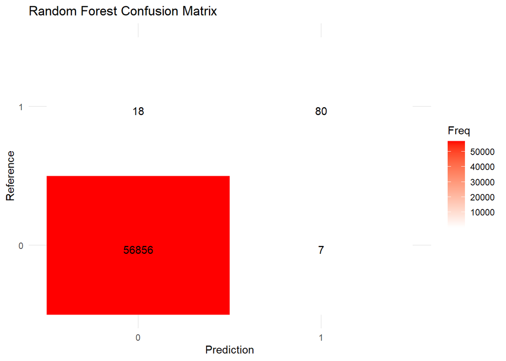

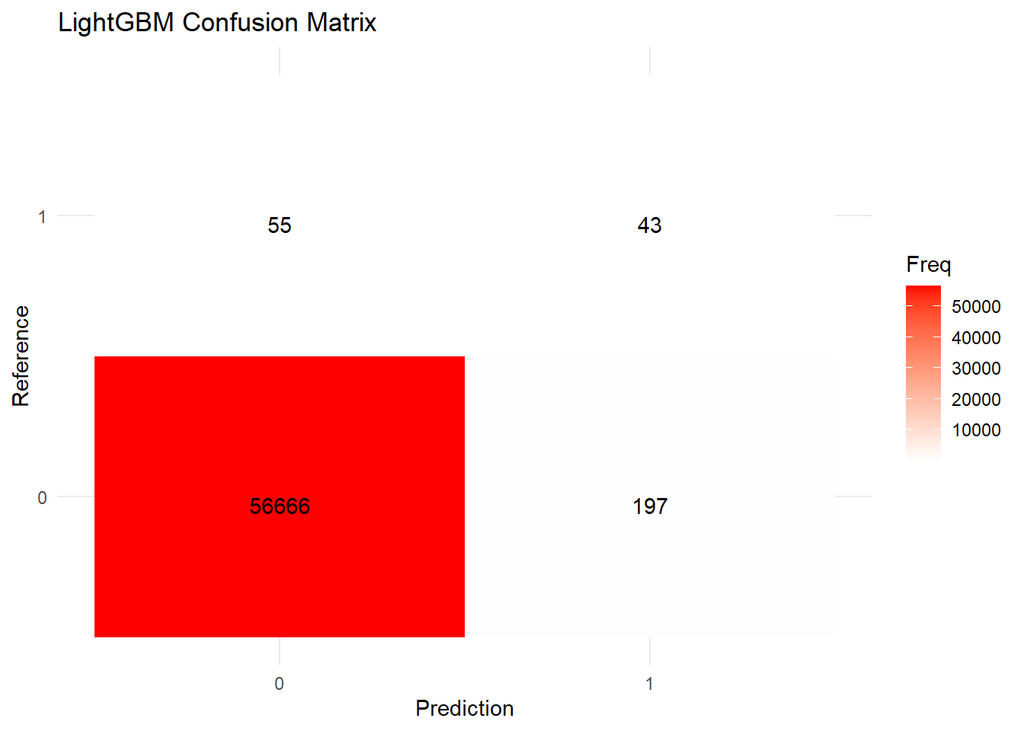

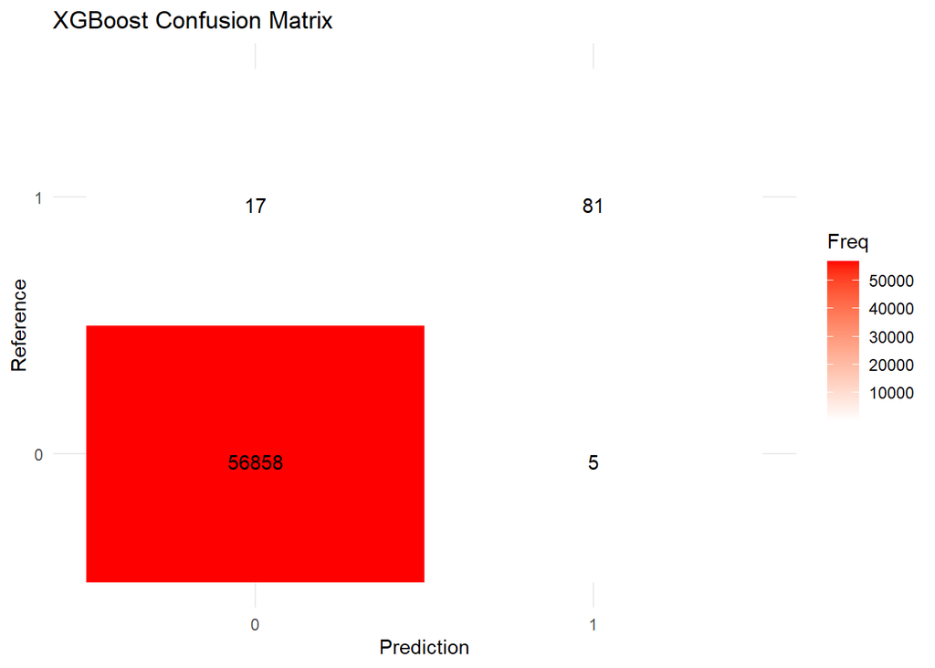

```
## Random Forest Metrics:
```

```
## Accuracy: 1
```

```
## Precision: 1
```

```
## Recall: 1
```

```
## F1 Score: 1
```

```
## LightGBM Metrics:
```

```
## Accuracy: 1
```

```
## Precision: 0.18
```

```
## Recall: 0.44
```

```
## F1 Score: 0.25
```

```
## XGBoost Metrics:
```

```
## Accuracy: 1
```

```
## Precision: 0.94
```

```
## Recall: 0.83
```

```
## F1 Score: 0.88
```

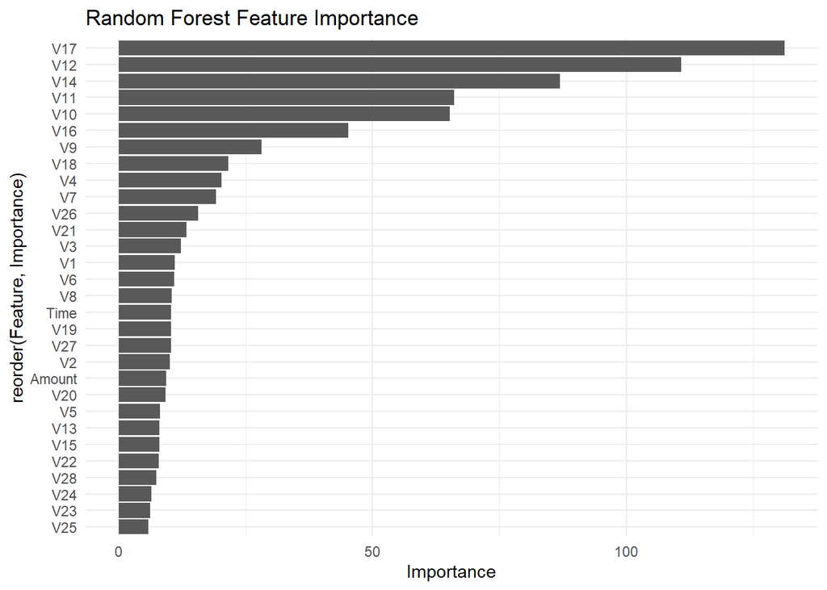

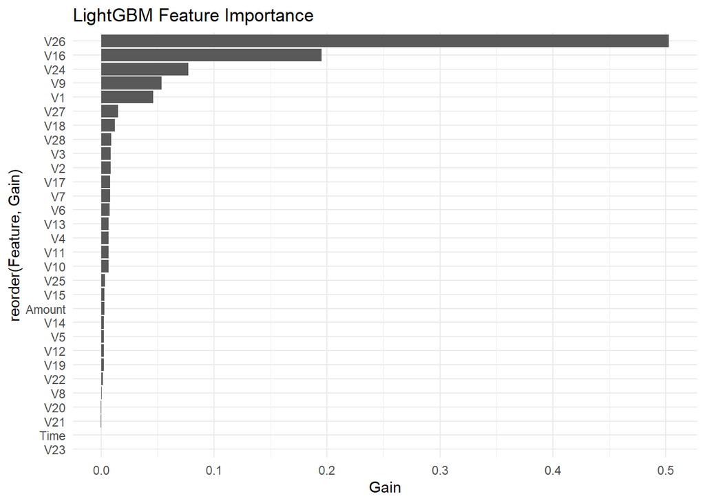

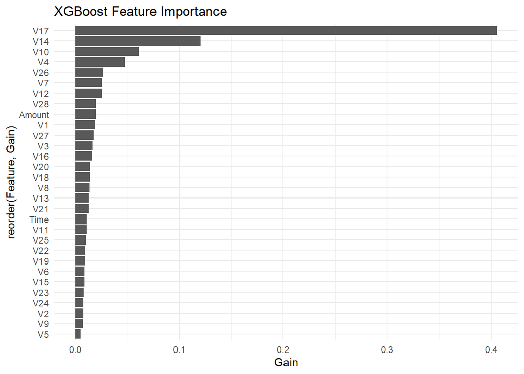

The Random Forest model provided an AUC score of `0.96`, indicating a strong discriminatory performance between fraudulent and non-fraudulent actions.

The LightGBM model provided an AUC score of `0.71`, indicating a weaker performance, but strong enough to distinguish between each class.

The XGBoost model provided an AUC score of `0.99`, being the strongest result out of the three models used, and the most optimal model in this scenario to detect fraud.